# R Commands for Sampling

Derek Sonderegger

August 27, 2014

# The sample command

We often need to actually draw a random sample from a sample frame. Older textbooks suggest methods that rely on tables of random numbers but that is antiquated. Instead we’ll use R.

The main function we’ll use is `sample(x, size, replace=FALSE)}`. Its arguments are:

| Argument | Purpose |
| --- | --- |
| x | a vector of elements to be sampled from (i.e. the sampling frame) |
| size | the size of the resulting sample |
| replace | Should the sampling be done with replacement (defaults to sampling without replacement) |

Suppose we want to choose 3 values from the vector 1, 2, …, 10.

```r
frame <- 1:10
frame
```

```
##  [1]  1  2  3  4  5  6  7  8  9 10
```

```r
sample(frame, 3)
```

```
## [1]  8 10  4
```

We can use this to sample rows from a data frame as well. Old Faithful is a geyser in Yellowstone National Park. R includes a data set that has wait times and eruption times. The data set has 272 observations. Suppose we wish to sample 20 of them

```r
str(faithful)
```

```
## 'data.frame':    272 obs. of  2 variables:
##  $ eruptions: num  3.6 1.8 3.33 2.28 4.53 ...
##  $ waiting  : num  79 54 74 62 85 55 88 85 51 85 ...
```

```r
index <- sample( 1:272, 20 )          # figure out which rows are to be selected
index
```

```
##  [1] 103 241 150 147 256   3 263  29 255 100 168 221  98  51 140  80 182
## [18] 116  49 198
```

```r
small.faithful <- faithful[ index, ]  # new data.frame with only those rows
str(small.faithful)
```

```
## 'data.frame':    20 obs. of  2 variables:
##  $ eruptions: num  2.1 4.15 1.8 4.63 3.82 ...
##  $ waiting  : num  49 75 53 80 80 74 58 78 88 82 ...
```

# A simulation exploring Simple Random Sampling

Consider the following data that might represent the number of dwellings, trees, or animals in a particular patch.

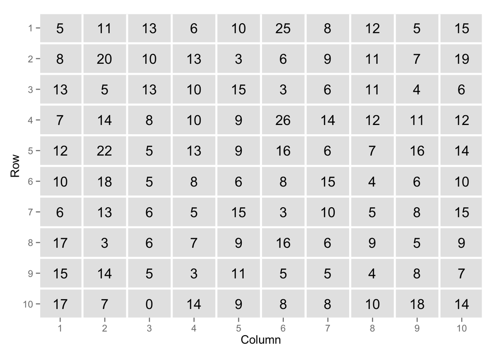

I have stored this data in R in a data.frame called “df” which is the the sample frame. Notice, that in practice we don’t know the y-values and we start our sampling project with just the row and column markers.

```r
str(df)
```

```
## 'data.frame':    100 obs. of  3 variables:
##  $ row: int  1 2 3 4 5 6 7 8 9 10 ...
##  $ col: int  1 1 1 1 1 1 1 1 1 1 ...
##  $ y  : int  5 8 13 7 12 10 6 17 15 17 ...
```

We are interested in trying to estimate the total number of objects in this grid along with the mean number of objects per grid. Because we have the full data (because this is a toy example) we can calculate them (along with the population variance).

```r
tau    <-  sum( df$y )
mu     <- mean( df$y )
sigma2 <-  var( df$y )
sigma  <- sqrt( sigma2 )

cbind( tau, mu, sigma2, sigma) # print these all in one row
```

```
##      tau  mu sigma2 sigma
## [1,] 990 9.9  24.86 4.986
```

From the theory we have derived, we think that the for a sample of size $n=10$ that the variance of $\bar{y}$ under the two schemes should be

$Var\left( \bar{y}_{SRS-WOR} \right) = \left( 1 - \frac{n}{N} \right) \frac{ \sigma^2 }{n}$ $Var\left( \bar{y}_{SRS-WR} \right) = \left( 1 - \frac{1}{N} \right) \frac{ \sigma^2 }{n}$

```r
n <- 10
N <- 100
var_ybar_SRSWOR <- (1 - n/N) * sigma2/n
var_ybar_SRSWR  <- (1 - 1/N) * sigma2/n

cbind( var_ybar_SRSWOR, var_ybar_SRSWR )
```

```
##      var_ybar_SRSWOR var_ybar_SRSWR
## [1,]           2.237          2.461
```

## Taking one sample from the population

Suppose that we don’t actually know the y values associated with each unit, and we wish to estimate the total number of the population. We’ll do this by sampling 10 units from the sample frame.

```r
my_sample <- df[sample(1:100, 10), ]
str( my_sample )
```

```
## 'data.frame':    10 obs. of  3 variables:
##  $ row: int  5 2 3 7 8 7 6 2 6 3
##  $ col: int  7 8 3 6 7 5 3 10 1 4
##  $ y  : int  6 11 13 3 6 15 5 19 10 10
```

These 10 samples correspond to the following units…

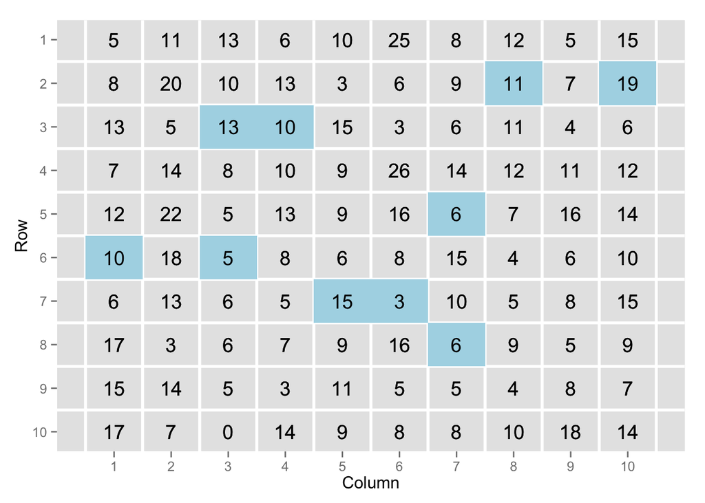

We can calculate the sample mean and estimate of the population total via the following

```r
ybar    <- mean( my_sample$y )
tau.hat <- 100 * ybar

cbind( tau.hat, ybar )
```

```
##      tau.hat ybar
## [1,]     980  9.8
```

## Taking many samples from the population

One way to compare the quality of different sampling schemes is to create a toy data set as we have in this example and then repeatedly sample from it using both methods. For this example, we’ll repeatedly sample from our population using both SRS-WOR and SRS-WR.

```r
# set up a data.frame to store the results from each simulation
results <- data.frame(ybar=NULL,
                      type=factor(NULL, levels=c('SRS-WOR','SRS-WR')))

n <- 10         # define the sample size
N <- nrow(df)   # define the population size
M <- 5000       # how many simulations to do for each sampling type

# do the Sampling Without Replacement simulations
for( k in 1:M ){
  my_sample <- df[sample(1:N, n), ]
  results <- rbind(results, data.frame(ybar=mean(my_sample$y),
                                       type='SRS-WOR',
                                       n=n))
}

# do the Sampling with Replacement simulations
for( k in 1:M ){
  my_sample <- df[sample(1:N, n, replace = TRUE), ]
  results <- rbind(results, data.frame(ybar=mean( my_sample$y),
                                       type='SRS-WR',
                                       n=n))
}
```

Now that the simulations have been run, we need to summarize the simulations. We’ll do this in two ways. First we’ll look at the mean and variance of sampling type.

```r
results %.%
  group_by(type) %.%
  summarize( E.ybar   = mean(ybar),
             V.ybar   =  var(ybar),
             StD.ybar =   sd(ybar))
```

```
## Source: local data frame [2 x 4]
##
##      type E.ybar V.ybar StD.ybar
## 1 SRS-WOR  9.911  2.230    1.493
## 2  SRS-WR  9.881  2.394    1.547
```

The second way to summarize our simulations is to make histograms of the $\bar{y}$ values.

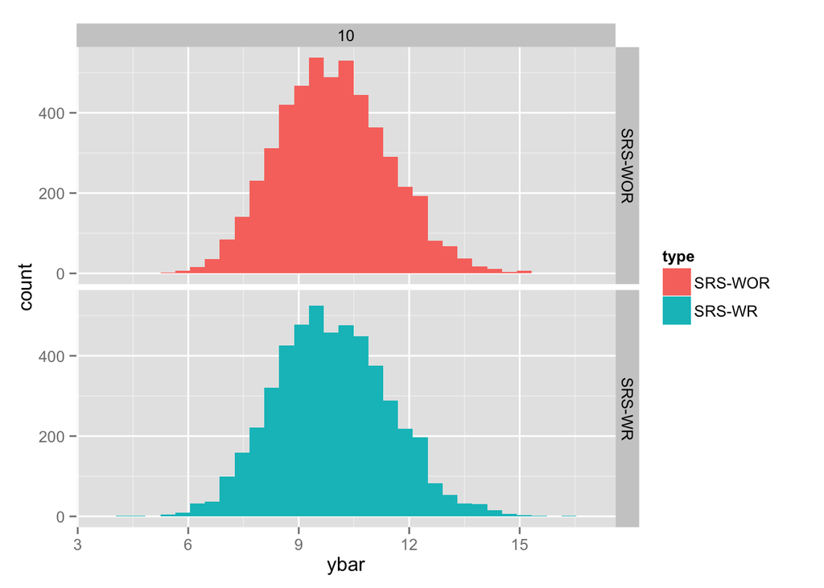

```r
library(ggplot2)
ggplot(results, aes(x=ybar, fill=type)) +
  geom_histogram() +
  facet_grid( type ~ n )
```